```r
library(readr)
bc = read_delim("GEN00067700-barcodes.txt", delim=" ", progress=FALSE)
library(dplyr)
grouped = bc %>%
  group_by(barcode, index) %>%
  summarise(count=n(), bcq=mean(barcodeq), iq=mean(indexq))
```

# Summary stats

There are 207548 unique barcode-index pairs and of those 5250 are seen more than 10 times.

We can see below that there is are a small set of barcode-index pairs that are represented a high number of times.

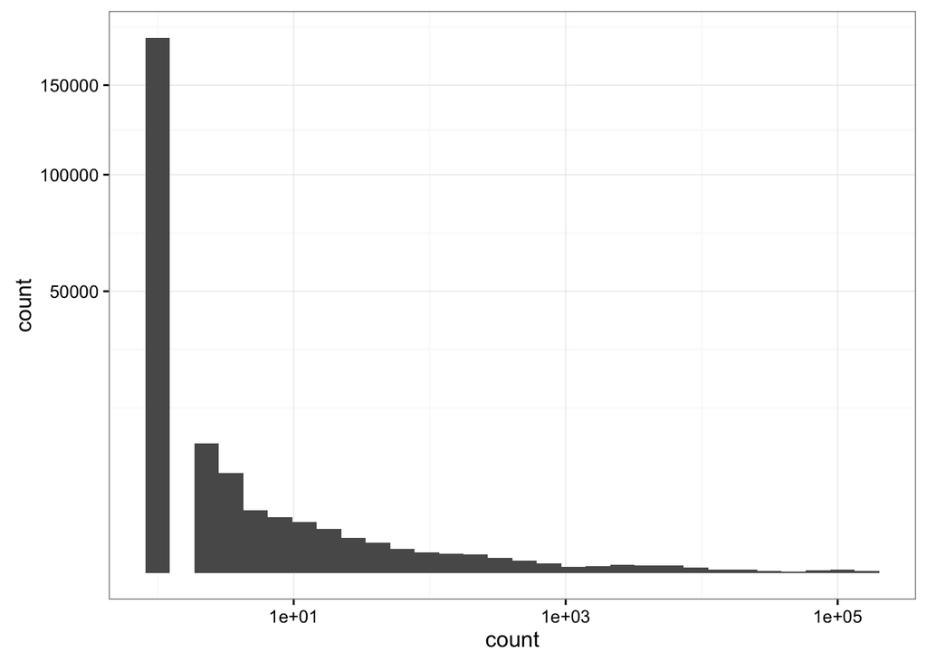

```r
library(ggplot2)
ggplot(grouped, aes(count)) + geom_histogram() + theme_bw() +
  scale_x_log10() + scale_y_sqrt()
```

# Known barcodes

```r
kbc = read_csv("../metadata/barcode.csv")
kin = read_csv("../metadata/index.csv")
grouped$kin = grouped$index %in% kin$rc
grouped$kbc = grouped$barcode %in% kbc$anti_sense
grouped$known = grouped$kin & grouped$kbc
grouped$known = ifelse(grouped$known, "known", "unknown")
```

Here we do a bunch of transformations to get the expected index-barcode pairs in a useful format. We take all the expected barcode matchings for each experiment and each pool separately, and then determine which indexes should have which barcodes. Then we combine them all together at the end.

```r
expected = read_csv("../metadata/GEN00067700-indexpairs.csv", progress=FALSE)
mcneu = read_tsv("../metadata/McNeu.tsv", progress=FALSE) %>%
  mutate(pool="McNeu Pool") %>%
  left_join(expected, by=c("pool"="bcid")) %>%
  select(-pool)
hmler = read_tsv("../metadata/HMLER.tsv") %>%
  mutate(pool="HMLER Pool") %>%
  left_join(expected, by=c("pool"="bcid")) %>%
  select(-pool)
poola = read_tsv("../metadata/PoolA.csv") %>%
  mutate(pool="Pool A") %>%
  left_join(expected, by=c("pool"="bcid")) %>%
  select(-pool)
expected = subset(expected, !bcid %in% c("McNeu Pool", "HMLER Pool", "Pool A"))
expected$bcid = as.integer(expected$bcid)
expected = expected %>% bind_rows(mcneu, hmler, poola) %>%
  left_join(kbc, by=c("bcid"="id")) %>%
  select(anti_sense.y, anti_sense.x)
colnames(expected) = c("ebarcode", "eindex")
expected$pair = paste(expected$ebarcode, expected$eindex, sep=":")
write_csv(expected, "expected-reformat.csv")
```

That was a bunch of joining and merging, so let’s make sure we did it correctly. We’re expecting 10 indexes to have 2 barcodes each, 3 indexes to have 30 barcodes (HMLER Pool), 6 indexes to have 33 barcodes (McNeu pool) and 1 index to have 6 barcodes (Pool A). That is a total of 314 barcode index pairs. There are 314 rows in the expected barcode data frame, once we are done with all the merging, so it looks like we did the merging correctly.

```r
grouped$pair = paste(grouped$barcode, grouped$index, sep=":")
grouped$expected = grouped$pair %in% expected$pair
known = subset(grouped, known == "known")
```

We only only see 269 of the 314 expected barcode-index pairs in this dataset. Some indexes are missing expected barcodes:

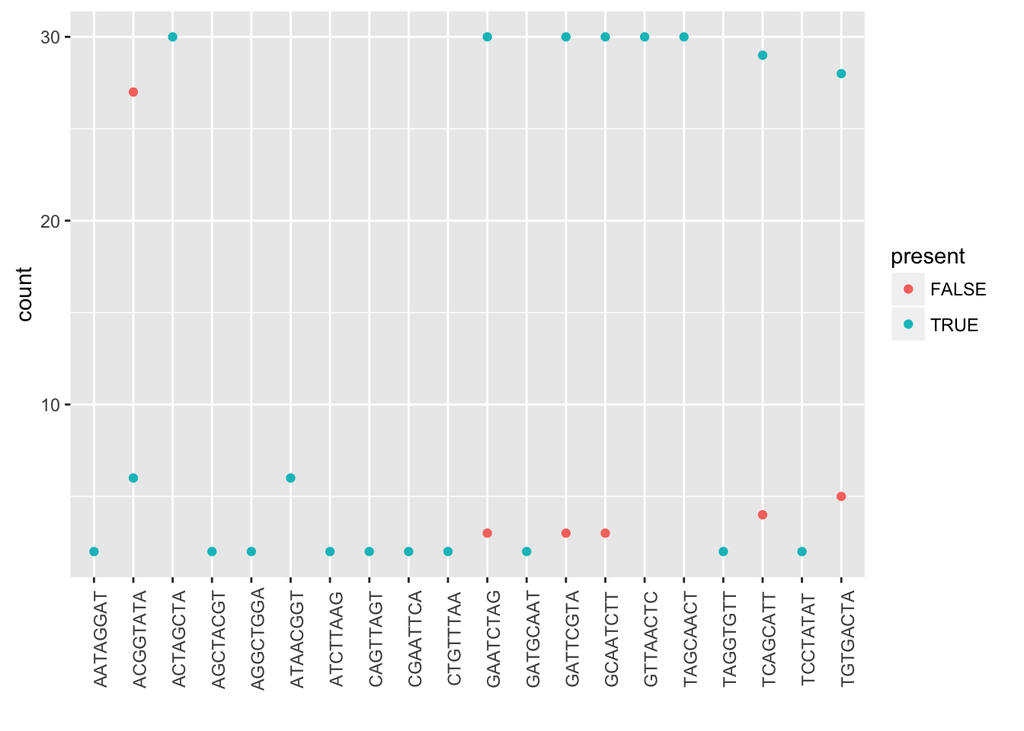

```r
missing_pairs = expected %>%
  mutate(present=pair %in% grouped$pair) %>%
  group_by(eindex, present) %>% summarise(count=n())
ggplot(missing_pairs, aes(eindex, count, color=present)) +
  geom_point() +
  xlab("") +
  theme(axis.text.x  = element_text(angle=90))
```

`ACGGTATA` looks like it is a failed library. There are only 25 total reads matching this index in the library.

I wrote out the barcode-index pairs with counts, the mean of the barcode quality (bcq), the mean of the index quality (iq), whether or not the index is a known index (kin), whether or not the barcode is a known barcode (kin), and whether or not the barcode-index pair is expected (known).

```r
write.table(grouped, file="all-barcode-index-unfiltered.csv", col.names=TRUE, row.names=FALSE, quote=FALSE, sep=",")
```

Now we can see if we mark up the barcode-index pairs with whether or not they are from the known barcode and known index files, we find that there are 820 barcode-index pairs and 269 expected barcode-index pairs.

If we plot the histograms separating out whether they are a known or unknown barcode-index pair, we can see that the known barcode-index pairs have many more reads associated with them than the unknown barcode-index pairs.

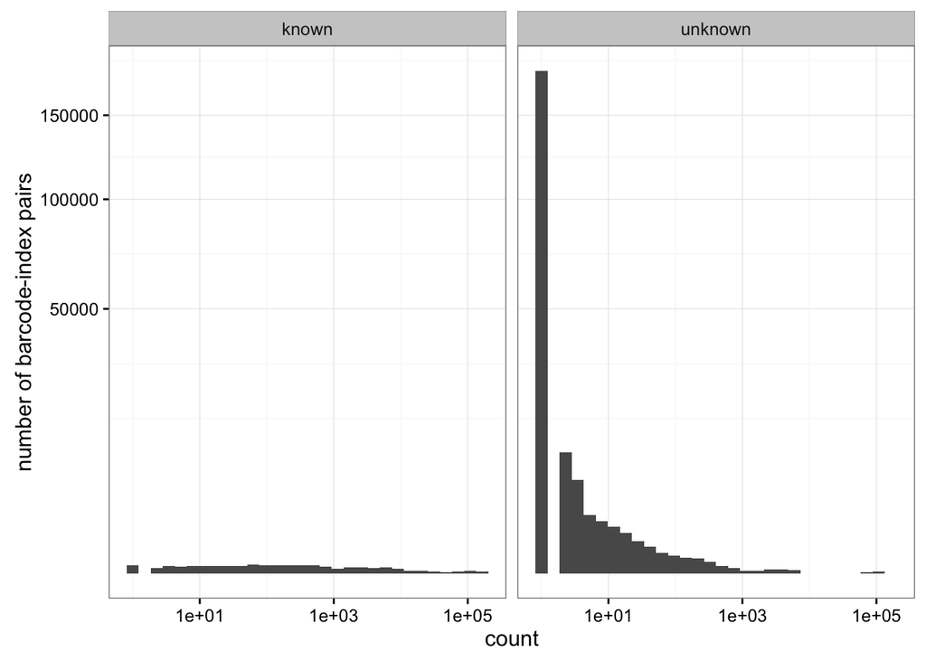

```r
library(ggplot2)
ggplot(grouped, aes(count)) + geom_histogram() + theme_bw() +
  facet_wrap(~known) +
  scale_x_log10() + scale_y_sqrt() +
  ylab("number of barcode-index pairs")
```

We can see that the PHRED quality of the known barcode-index pairs has a tight distribution:

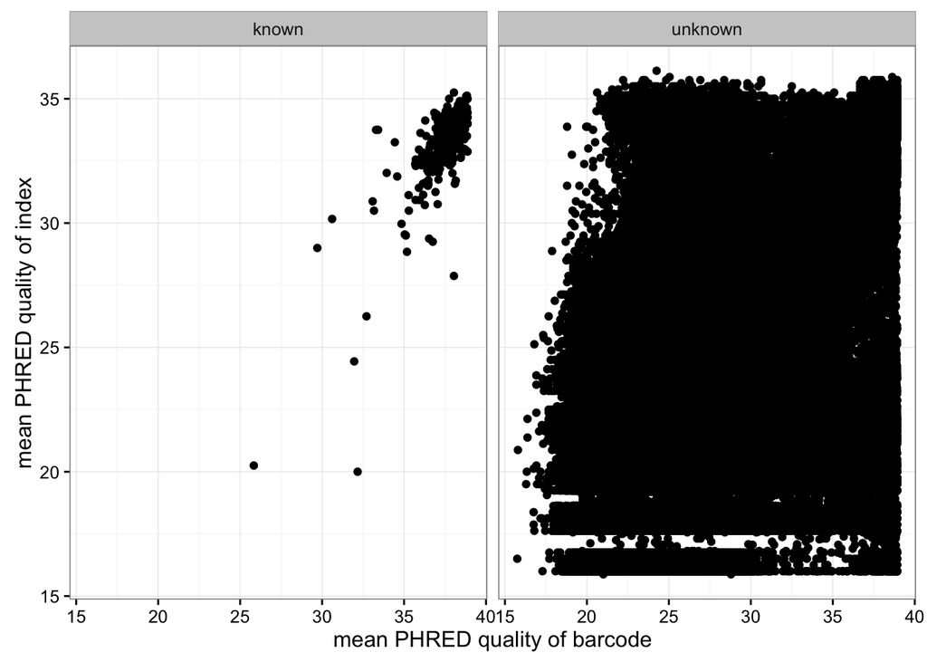

```r
ggplot(grouped, aes(bcq, iq)) + geom_point() + theme_bw() +
  facet_wrap(~known) +
  ylab("mean PHRED quality of index") +
  xlab("mean PHRED quality of barcode")
```

Here you can see that if we filter for only known barcodes and indexes, they tend to have both a high index and barcode quality compared to unknown sequences.

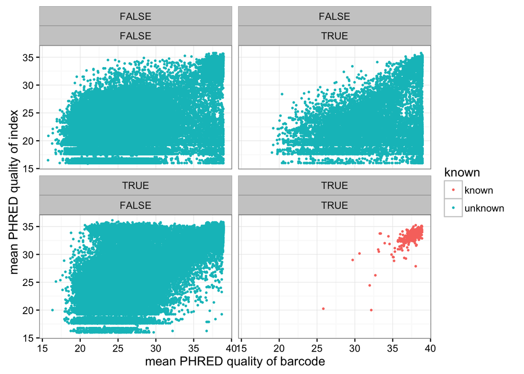

```r
ggplot(grouped, aes(bcq, iq, color=known)) + geom_point(size=0.5) + theme_bw() +
  facet_wrap(~kin+kbc) +
  ylab("mean PHRED quality of index") +
  xlab("mean PHRED quality of barcode")
```

If we look at the expected barcode-index pairings, we can see that there is not much of a difference in the distribution of quality of the barcode-index pairs for the pairs we expect (TRUE) and the pairs we do not expect (FALSE). Filtering on quality will not help these results.

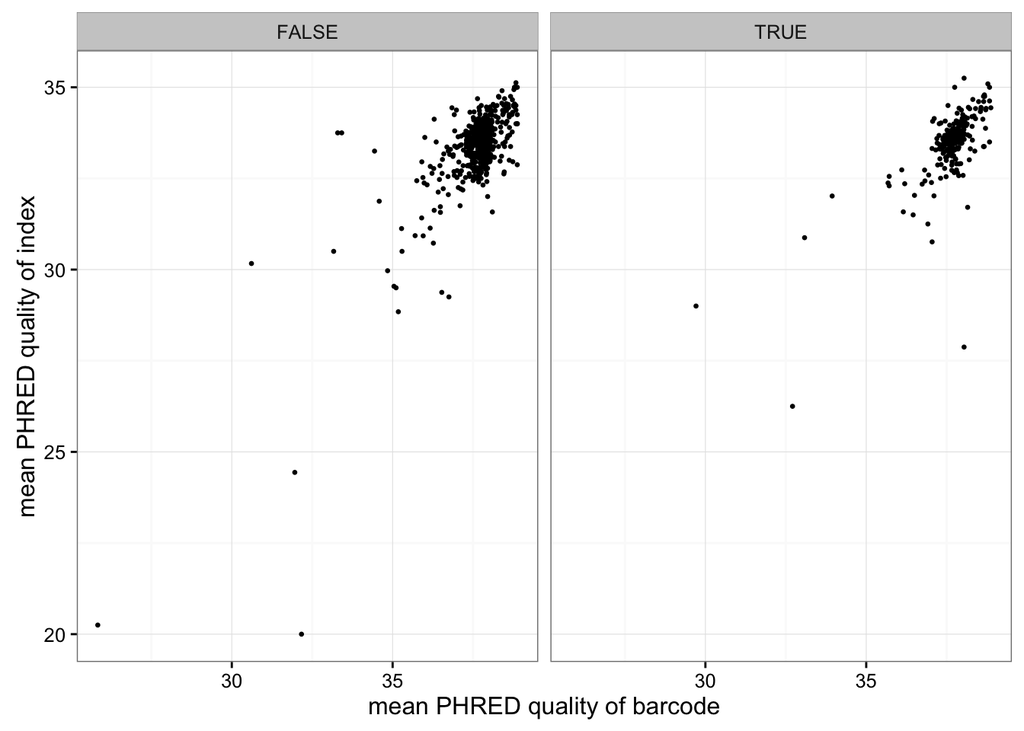

```r
ggplot(subset(grouped, known == "known"), aes(bcq, iq)) +
  geom_point(size=0.5) + theme_bw() +
  facet_wrap(~expected) +
  ylab("mean PHRED quality of index") +
  xlab("mean PHRED quality of barcode")
```

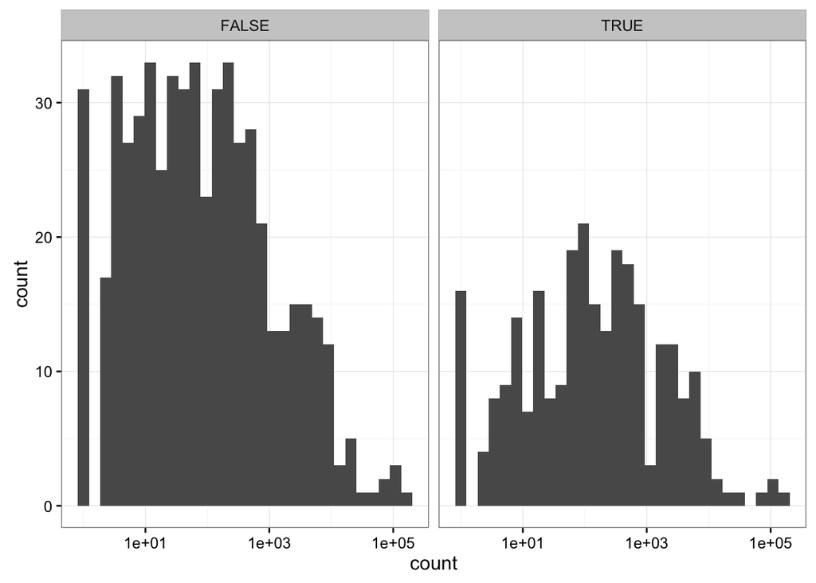

```r
ggplot(subset(grouped, known == "known"), aes(count)) +
  geom_histogram() + theme_bw() +
  facet_wrap(~expected) +
  scale_x_log10()
```

# Barcodes per index

We generally see more barcodes than we are expecting per index.

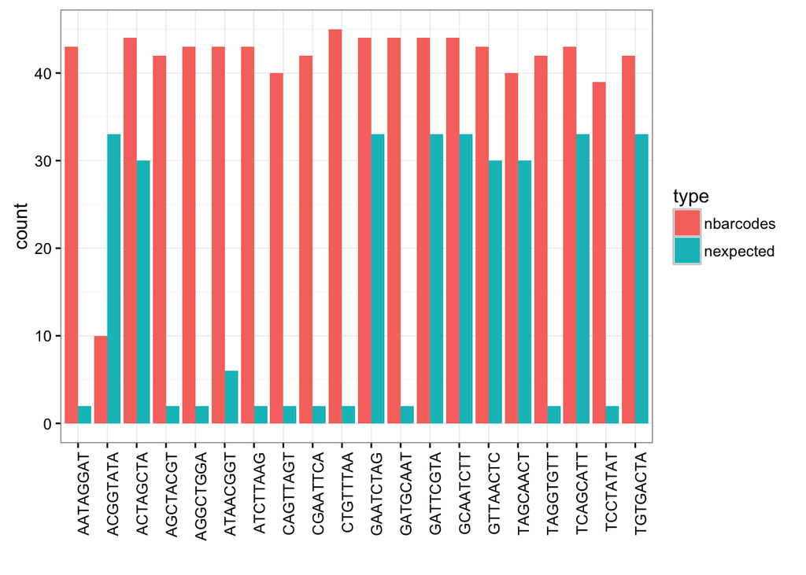

```r
expected_counts = expected %>% group_by(eindex) %>% summarise(nexpected=n())
barcode_per_index = known %>% group_by(index) %>% summarise(nbarcodes = n()) %>%
  left_join(expected_counts, by=c("index"="eindex")) %>%
  tidyr::gather("type", "count", 2:3)
index_per_barcode = known %>% group_by(barcode) %>% summarise(nindex = n())
ggplot(barcode_per_index, aes(index, count, fill=type)) +
  geom_bar(stat='identity', position='dodge') +
  theme_bw() +
  theme(axis.text.x = element_text(angle = 90, hjust = 1)) +
  xlab("")
```

# Barcodes counts for each index

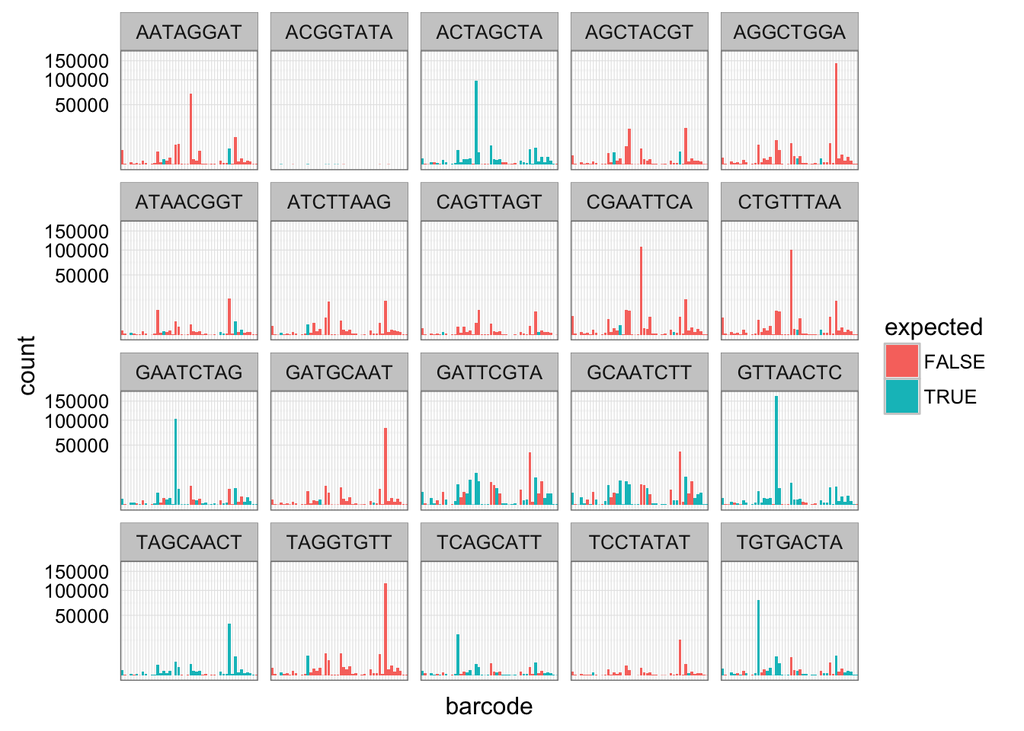

```r
ggplot(known, aes(barcode, count, fill=expected)) +
  facet_wrap(~index) + geom_bar(stat='identity') +
  scale_y_sqrt() +
  theme_bw() +
  theme(axis.ticks = element_blank(), axis.text.x = element_blank())
```

These aren’t lining up at all with what we were expecting, it looks a lot worse than the previous library. Let’s pick one of the indexes that are supposed to have just two barcodes “AATAGGAT” (top left) to look at more in depth.

```r
AATAGGAT = grouped %>%
  filter(index == "AATAGGAT")
AATAGGAT_known = subset(AATAGGAT, known == "known") %>% arrange(desc(count))
AATAGGAT_unknown = subset(AATAGGAT, known == "unknown")
```

There are 3589 barcodes identified for AATAGGAT. Of those, 43 have both a known barcode and a known index. 3546 do not have a known barcode and a known index. For the known barcode-index pairs, there are 108872 and for the uknown pairs there are 21996, so despite there being only a small number of entries where both the barcode and index are known, they have the majority of the counts, which is what we expect.

Looking at the top of the table, we can see the two barcodes that are the highest are not the barcodes we were expecting. We are expecting barcodes 64 and 68 but the top two are barcodes 54 and 44.

```r
knitr::kable(head(AATAGGAT_known))
```

| barcode | index | count | bcq | iq | kin | kbc | known | pair | expected |
| --- | --- | --- | --- | --- | --- | --- | --- | --- | --- |
| CTTTTTCAATCACTTTCAATTCAT | AATAGGAT | 70265 | 37.75629 | 33.70864 | TRUE | TRUE | known | CTTTTTCAATCACTTTCAATTCAT:AATAGGAT | FALSE |
| TCATTTACCAATCTTTCTTTATAC | AATAGGAT | 10903 | 37.96975 | 33.57417 | TRUE | TRUE | known | TCATTTACCAATCTTTCTTTATAC:AATAGGAT | FALSE |
| CTTTATCAATACATACTACAATCA | AATAGGAT | 5850 | 37.68771 | 33.69299 | TRUE | TRUE | known | CTTTATCAATACATACTACAATCA:AATAGGAT | FALSE |
| CTTTAATCTCAATCAATACAAATC | AATAGGAT | 5718 | 37.77878 | 33.66190 | TRUE | TRUE | known | CTTTAATCTCAATCAATACAAATC:AATAGGAT | FALSE |
| TCATAATCTCAACAATCTTTCTTT | AATAGGAT | 3604 | 37.88329 | 33.61137 | TRUE | TRUE | known | TCATAATCTCAACAATCTTTCTTT:AATAGGAT | TRUE |
| AAACAAACTTCACATCTCAATAAT | AATAGGAT | 3114 | 37.72649 | 33.63211 | TRUE | TRUE | known | AAACAAACTTCACATCTCAATAAT:AATAGGAT | FALSE |

I checked to see if we are making a mistake somewhere in this script by checking in the unprocessed sequences by grepping for the barcode and the index in the same read. This isn’t perfect since it doesn’t match the anchor sequences and doesn’t restrict the position the sequences are in, but gives a quick and dirty estimate to make sure we didn’t make a mistake anywhere:

```
TCATAATCTCAACAATCTTTCTTT (expected): 4006
CTTTTTCAATCACTTTCAATTCAT (top hit): 72315
```

# Output tables

The first table has the expected barcode-index pairings, reformatted to be easy to use in the script.

Expected barcode-index pairs file (reformatted)

This table is all of the identified barcode-index pairs from the sequence data (everything that matched the regex). It is unfiltered, and has columns indicating whether the barcode was known ‘kbc’ the index was known ‘kin’, both were known ‘known’ and if the barcode-index pair is expected ‘expected’. The count column is the total number of times we saw this barcode-index pairing.

Barcode-index pairings (unfiltered)

# Summary

Something is up, we are seeing barcodes in all kinds of samples we are not expecting. This isn’t simple crosstalk, because if that was the case we would see a low level of cross contamination but still see the main barcode signals popping out like we did in the first set of samples. It is entirely possible that I have screwed something up, but if I am, I can’t figure out where it is happening.